# Lateral connectivity analysis

### Model formula

This is the 2-equation parsimonious version we settled on — `lateral_connectivity` enters only the `water_res_time_z` equation (its sole causal pathway per the DAG), and `delta_DOC` regresses on the mediator `WRT` alone (no backdoor adjustment needed, since the total effect is unconfounded):

```r
bform <-
  bf(delta_DOC | mi(0.283) ~ 0 + Intercept +
       mi(water_res_time_z) +
       (0 + Intercept | site),
     family = student()) +

  bf(water_res_time_z | mi()  ~ 0 + n_dams_z + mi(dam_height_z) + slope_z +
       lateral_connectivity + solar_z,
     family = gaussian()) +

  bf(dam_height_z | mi()  ~ 0 + Intercept, family = gaussian()) +

  set_rescor(FALSE)

#detach("package:rethinking", unload = TRUE)

# Informative priors: shared parameters carry the same priors as in the main SCM (notebook.qmd);
# the three connectivity-level coefficients get weakly-informative normal(0, 1) priors (WRT is z-scored).
prio_conn <- c(
  prior(normal(0, 2.5),       class = "b", coef = "Intercept",          resp = "deltaDOC"),
  prior(normal(0, 0.1),       class = "b", coef = "miwater_res_time_z", resp = "deltaDOC"),
  prior(student_t(3, 0, 2.5), class = "sigma",                          resp = "deltaDOC"),
  prior(gamma(2, 0.1),        class = "nu",                             resp = "deltaDOC"),
  prior(normal(0, 2),         class = "sd", coef = "Intercept", group = "site", resp = "deltaDOC"),
  prior(normal(0.15, 0.075),  class = "b", coef = "n_dams_z",           resp = "waterrestimez"),
  prior(normal(0.15, 0.075),  class = "b", coef = "midam_height_z",     resp = "waterrestimez"),
  prior(normal(0, 0.075),     class = "b", coef = "slope_z",            resp = "waterrestimez"),
  prior(normal(0, 0.075),     class = "b", coef = "solar_z",            resp = "waterrestimez"),
  prior(normal(0, 1),         class = "b", coef = "lateral_connectivityNo_wetland",        resp = "waterrestimez"),
  prior(normal(0, 1),         class = "b", coef = "lateral_connectivityyes_not_connected", resp = "waterrestimez"),
  prior(normal(0, 1),         class = "b", coef = "lateral_connectivityyes_connected",     resp = "waterrestimez"),
  prior(normal(0, 0.5),       class = "sigma",                          resp = "waterrestimez"),
  prior(normal(0, 1),         class = "b", coef = "Intercept",          resp = "damheightz"),
  prior(normal(0, 0.5),       class = "sigma",                          resp = "damheightz"))

fit_connectivity <- brm(bform, data = m6_fit,
                        prior = prio_conn,
                        chains = 4,
                        cores = 10, seed = 42,
                        backend = "cmdstanr",
                        file = here("results","models_fit","fitconnectivity_informative"),
                        sample_prior = FALSE
)
```

```
Running MCMC with 4 chains, at most 10 in parallel...

Chain 1 Iteration:    1 / 2000 [  0%]  (Warmup)
Chain 2 Iteration:    1 / 2000 [  0%]  (Warmup)
Chain 3 Iteration:    1 / 2000 [  0%]  (Warmup)
Chain 4 Iteration:    1 / 2000 [  0%]  (Warmup)
Chain 2 Iteration:  100 / 2000 [  5%]  (Warmup)
Chain 4 Iteration:  100 / 2000 [  5%]  (Warmup)
Chain 1 Iteration:  100 / 2000 [  5%]  (Warmup)
Chain 2 Iteration:  200 / 2000 [ 10%]  (Warmup)
Chain 3 Iteration:  100 / 2000 [  5%]  (Warmup)
Chain 1 Iteration:  200 / 2000 [ 10%]  (Warmup)
Chain 2 Iteration:  300 / 2000 [ 15%]  (Warmup)
Chain 3 Iteration:  200 / 2000 [ 10%]  (Warmup)
Chain 1 Iteration:  300 / 2000 [ 15%]  (Warmup)
Chain 2 Iteration:  400 / 2000 [ 20%]  (Warmup)
Chain 3 Iteration:  300 / 2000 [ 15%]  (Warmup)
Chain 4 Iteration:  200 / 2000 [ 10%]  (Warmup)
Chain 1 Iteration:  400 / 2000 [ 20%]  (Warmup)
Chain 2 Iteration:  500 / 2000 [ 25%]  (Warmup)
Chain 3 Iteration:  400 / 2000 [ 20%]  (Warmup)
Chain 4 Iteration:  300 / 2000 [ 15%]  (Warmup)
Chain 1 Iteration:  500 / 2000 [ 25%]  (Warmup)
Chain 2 Iteration:  600 / 2000 [ 30%]  (Warmup)
Chain 3 Iteration:  500 / 2000 [ 25%]  (Warmup)
Chain 4 Iteration:  400 / 2000 [ 20%]  (Warmup)
Chain 1 Iteration:  600 / 2000 [ 30%]  (Warmup)
Chain 2 Iteration:  700 / 2000 [ 35%]  (Warmup)
Chain 3 Iteration:  600 / 2000 [ 30%]  (Warmup)
Chain 3 Iteration:  700 / 2000 [ 35%]  (Warmup)
Chain 1 Iteration:  700 / 2000 [ 35%]  (Warmup)
Chain 2 Iteration:  800 / 2000 [ 40%]  (Warmup)
Chain 2 Iteration:  900 / 2000 [ 45%]  (Warmup)
Chain 3 Iteration:  800 / 2000 [ 40%]  (Warmup)
Chain 1 Iteration:  800 / 2000 [ 40%]  (Warmup)
Chain 3 Iteration:  900 / 2000 [ 45%]  (Warmup)
Chain 4 Iteration:  500 / 2000 [ 25%]  (Warmup)
Chain 1 Iteration:  900 / 2000 [ 45%]  (Warmup)
Chain 2 Iteration: 1000 / 2000 [ 50%]  (Warmup)
Chain 2 Iteration: 1001 / 2000 [ 50%]  (Sampling)
```

[output cut: 43 more lines]

[output not shown]

```r
#summary(fit_connectivity)
```

Now we are going to extract the posterior draws from the model we fitted:

```r
draws <- as_draws_df(fit_connectivity)

mean_no_wetland    <- draws$b_waterrestimez_lateral_connectivityNo_wetland
mean_not_connected <- draws$b_waterrestimez_lateral_connectivityyes_not_connected
mean_connected     <- draws$b_waterrestimez_lateral_connectivityyes_connected

effect_wrt_not_connected <- mean_not_connected - mean_no_wetland
effect_wrt_connected     <- mean_connected - mean_no_wetland

s1 <- summarise_draws(data.frame(
  effect_wrt_not_connected = effect_wrt_not_connected,
  effect_wrt_connected     = effect_wrt_connected
))

wrt_to_doc <- draws$bsp_deltaDOC_miwater_res_time_z

total_effect_not_connected <- effect_wrt_not_connected * wrt_to_doc
total_effect_connected     <- effect_wrt_connected * wrt_to_doc

s2 <- summarise_draws(data.frame(
  total_effect_not_connected = total_effect_not_connected,
  total_effect_connected     = total_effect_connected
))

effects_df <- data.frame(
  not_connected = total_effect_not_connected,
  connected     = total_effect_connected
) %>%
  pivot_longer(everything(), names_to = "contrast", values_to = "effect") %>%
  mutate(contrast = recode(contrast,
                           "not_connected" = "Yes, not connected\nvs No wetland",
                           "connected"      = "Yes, connected\nvs No wetland"))
```

Then plot the results as contrasts (Appendix S1: Figure S9):

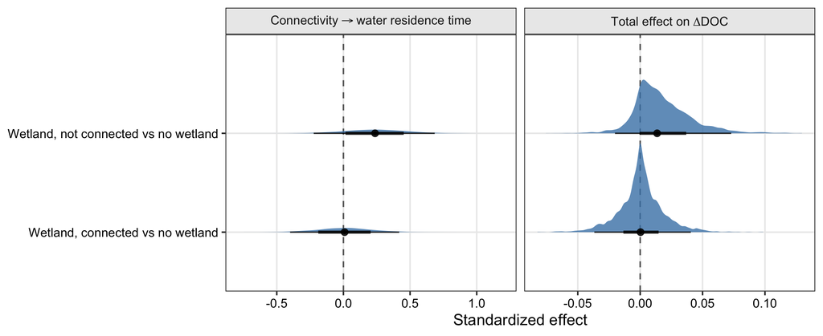

Figure 4: **Appendix S1, Figure S9. Effect of lateral stream-wetland connectivity.** Left: the contrasts `effect_wrt_not_connected` and `effect_wrt_connected`, i.e. the effect of each connectivity level on water residence time relative to sites without wetland. Right: `total_effect_not_connected` and `total_effect_connected`, the total mediated effect on $\Delta$DOC, obtained by multiplying each contrast by the WRT to $\Delta$DOC coefficient `wrt_to_doc`. Points are posterior medians; thick and thin bars are the 66% and 95% credible intervals; the dashed line marks zero.

```r
df_s9 <- bind_rows(
  tibble(stage = "A", contrast = "Wetland, not connected vs no wetland", draw = effect_wrt_not_connected),
  tibble(stage = "A", contrast = "Wetland, connected vs no wetland",     draw = effect_wrt_connected),
  tibble(stage = "B", contrast = "Wetland, not connected vs no wetland", draw = total_effect_not_connected),
  tibble(stage = "B", contrast = "Wetland, connected vs no wetland",     draw = total_effect_connected)) |>
  mutate(contrast = factor(contrast, levels = rev(c("Wetland, not connected vs no wetland", "Wetland, connected vs no wetland"))))
lab_s9 <- as_labeller(c(A = "Connectivity%->%'water residence time'", B = "'Total effect on'~Delta*'DOC'"), label_parsed)
(p_s9 <- ggplot(df_s9, aes(x = draw, y = contrast)) +
  geom_vline(xintercept = 0, linetype = 2, colour = "grey40") +
  stat_halfeye(.width = c(.66, .95), fill = "steelblue", alpha = .8) +
  facet_wrap(~stage, scales = "free_x", labeller = lab_s9) +
  labs(x = "Standardized effect", y = NULL) +
  theme_bw(base_size = 15) +
  theme(axis.text = element_text(color = "black"), panel.grid.minor = element_blank(),
        strip.background = element_rect(fill = "grey92")))
ggsave(here("results", "figures", "figS9_connectivity.png"), p_s9, width = 11, height = 4.5, dpi = 300)
```

**NoteWhat Figure 4 shows**

Naming each posterior quantity explicitly (standardized effect, 90% credible interval, posterior probability of being positive):

- **`effect_wrt_not_connected`** — an unconnected wetland versus no wetland, effect on water residence time: +0.23 [-0.15, 0.61], P(> 0) = 0.85
- **`effect_wrt_connected`** — a connected wetland versus no wetland, effect on water residence time: +0.01 [-0.34, 0.36], P(> 0) = 0.52
- **`wrt_to_doc`** — the mediating coefficient from water residence time to $\Delta$DOC: +0.08 [0.00, 0.14], P(> 0) = 0.96
- **`total_effect_not_connected`**: +0.02 [-0.01, 0.06], and **`total_effect_connected`**: +0.00 [-0.03, 0.03]

### Conclusions:

**Important**

- We find null total effect of lateral connectivity on ΔDOC via the water-residence-time pathway: both 90% CIs overlap zero, with small magnitudes on the standardized scale.
- We also see the WRT → ΔDOC mediating path itself is weak, with its CI touching ~0.00 at the lower bound — limiting our ability to detect a total effect even if connectivity strongly affected WRT.
- We treat this as power-limited rather than strong evidence of no effect — only 13 sites (~7%) are `yes_connected` and 11 (~6%) are `yes_not_connected`, so wide intervals likely reflect limited data rather than a true null.